# Lab1-MarkDown

Annika Kufrovich

February 2, 2018

[output not shown]

## Intro

The Hollywood Movies data set looks at movies released between 2007 and 2013. Obervations include the studio that released the movie, Rottentomatoes score, Audiences score, General theme, Genre, year of release, and the number of screens showing the film opening week. It also includes financial observations (in millions) of the movies’ opening weekend, Domestic gross earnings, Foreign gross earnings, World gross earnings (a combination of the previous two), budget of the movie, profitability, and open profit.

First Rows of HollywoodMovies

| Movie | LeadStudio | RottenTomatoes | AudienceScore | Story | Genre | TheatersOpenWeek | OpeningWeekend | BOAvgOpenWeekend | DomesticGross | ForeignGross | WorldGross | Budget | Profitability | OpenProfit | Year |
| --- | --- | --- | --- | --- | --- | --- | --- | --- | --- | --- | --- | --- | --- | --- | --- |
| Spider-Man 3 | Sony | 61 | 54 | Metamorphosis | Action | 4252 | 151.1 | 35540 | 336.53 | 554.34 | 890.87 | 258 | 345.30 | 58.57 | 2007 |
| Shrek the Third | Paramount | 42 | 57 | Quest | Animation | 4122 | 121.6 | 29507 | 322.72 | 476.24 | 798.96 | 160 | 499.35 | 76.00 | 2007 |
| Transformers | Paramount | 57 | 89 | Monster Force | Action | 4011 | 70.5 | 17577 | 319.25 | 390.46 | 709.71 | 150 | 473.14 | 47.00 | 2007 |
| Pirates of the Caribbean: At World’s End | Disney | 45 | 74 | Rescue | Action | 4362 | 114.7 | 26302 | 309.42 | 654.00 | 963.42 | 300 | 321.14 | 38.23 | 2007 |
| Harry Potter and the Order of the Phoenix | Warner Bros | 78 | 82 | Quest | Adventure | 4285 | 77.1 | 17998 | 292.00 | 647.88 | 939.89 | 150 | 626.59 | 51.40 | 2007 |
| I Am Legend | Warner Bros | 69 | 69 | Quest | Thriller | 3606 | 77.2 | 21411 | 256.39 | 328.96 | 585.35 | 150 | 390.23 | 51.47 | 2007 |

## Summary of Data

```
##                  Action   Adventure   Animation   Biography      Comedy
##         279         166          30          51          14         177
##       Crime Documentary       Drama     Fantasy      Horror     Musical
##          15           7         109           6          52           4
##     Mystery     Romance    Thriller
##           5          20          35
```

```
##    Min. 1st Qu.  Median    Mean 3rd Qu.    Max.    NA's
##    0.00   20.00   35.00   56.12   75.00  300.00      73
```

```
##    Min. 1st Qu.  Median    Mean 3rd Qu.    Max.
##    0.06   17.57   40.41   68.16   89.25  760.50
```

```
## # A tibble: 15 x 2
##          Genre `mean(Budget)`
##         <fctr>          <dbl>
##  1                         NA
##  2      Action             NA
##  3   Adventure       80.35000
##  4   Animation      108.81373
##  5   Biography       35.07143
##  6      Comedy             NA
##  7       Crime       33.32000
##  8 Documentary             NA
##  9       Drama             NA
## 10     Fantasy       74.45000
## 11      Horror             NA
## 12     Musical       53.50000
## 13     Mystery       47.80000
## 14     Romance       36.85000
## 15    Thriller       58.03429
```

```
## # A tibble: 15 x 2
##          Genre `mean(DomesticGross)`
##         <fctr>                 <dbl>
##  1                          63.66516
##  2      Action              96.70151
##  3   Adventure              87.39517
##  4   Animation             130.89431
##  5   Biography              63.17643
##  6      Comedy              52.65585
##  7       Crime              52.13600
##  8 Documentary              34.37857
##  9       Drama              39.72907
## 10     Fantasy             107.37667
## 11      Horror              40.92827
## 12     Musical              67.91250
## 13     Mystery              43.80400
## 14     Romance              63.28750
## 15    Thriller              83.38597
```

The three variables we’ll be looking at are Genre, Budget, and Domestic Gross earning, with the latter 2 in millions. Of the 970 movies recorded, 279 were not assigned a Genre while all others were assigned to one of 14 Genres, however some of the Genres have less than 10 entries which may make them difficult to compare those groups to other genres. With only 73 NA Budget entries this variable should be easy to work with but causes a few NA averages when movies were grouped by Genre. The average DomesticGross Income overall was 68.1625443 and there appear to be no missing values in Domestic Gross income making it easy to use.

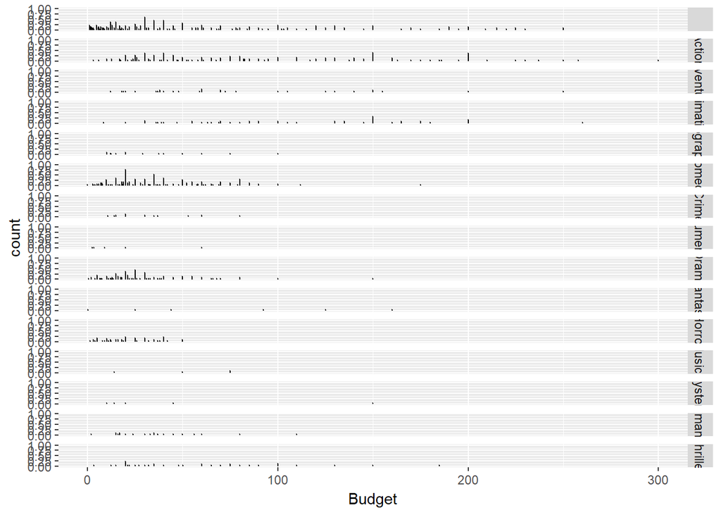

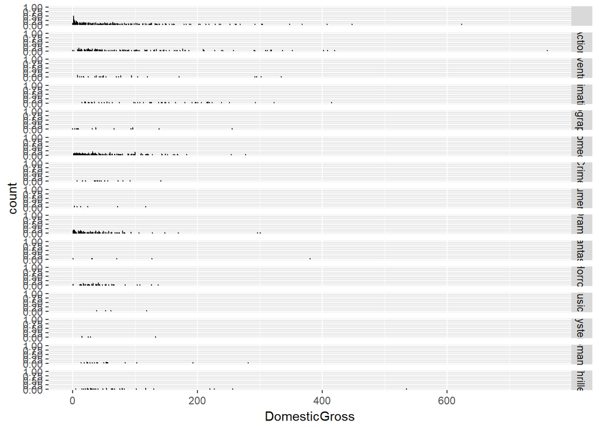

## Conclusion

There definitely appear to be differences between roup however due to lack of some data entries and underrepresented Genres, there are limits to what groups can be compared.